# Práctica 1 – Herramientas Exploratorias para una Variable

Jordi Gisbert

2026-04-09

```r
library(readr)
library(dplyr)
library(ggplot2)
library(knitr)
```

# 1. Hoja de datos

Lo primero es cargar el fichero de datos. En Statgraphics se abría con `Archivo > Abrir StatFolio`; aquí leemos directamente el CSV. Los espacios en blanco que tienen algunos valores de texto los limpiamos con `trimws`.

```r
datos <- read_csv(
  "CURS8990-Codif.csv",
  locale = locale(encoding = "latin1"),
  show_col_types = FALSE
)

# Nos quedamos con las 11 variables de interés
datos <- datos[, 1:11]
names(datos) <- trimws(names(datos))
datos <- datos %>% mutate(across(where(is.character), trimws))

glimpse(datos)
```

```
## Rows: 131
## Columns: 11
## $ SEXO       <chr> "chicos", "chicos", "chicos", "chicos", "chicos", "chicos",…
## $ EDAD       <dbl> 20, 21, 22, 22, 22, 20, 22, 23, 21, 21, 21, 22, 20, 20, 20,…
## $ MES        <dbl> 1, 6, 10, 4, 7, 11, 7, 10, 3, 6, 3, 6, 4, 12, 9, 10, 6, 5, …
## $ ESTATURA   <dbl> 183, 185, 165, 174, 175, 175, 174, 159, 177, 180, 175, 162,…
## $ PESO       <dbl> 76, 72, 75, 70, 70, 70, 65, 54, 72, 73, 68, 48, 65, 74, 72,…
## $ POLITICA   <chr> "izquierda", "centro", "pasan", "pasan", "pasan", "derecha"…
## $ DIGITO     <dbl> 5, 8, 8, 6, 7, 3, 7, 5, 8, 5, 7, 3, 7, 4, 9, 4, 3, 7, 4, 5,…
## $ RESIDENCIA <chr> "piso", "otra", "familia", "residencia", "piso", "familia",…
## $ TRANSPORTE <chr> "a pie", "coche", "t publico", "a pie", "a pie", "compañero…
## $ TIEMPO     <dbl> 15, 10, 30, 15, 20, 60, 5, 65, 15, 15, 10, 75, 30, 30, 15, …
## $ PROBLEMA   <chr> "desigualdad", "terrorismo", "desigualdad", "droga", "desig…
```

Las **columnas** son las variables y las **filas** son los alumnos encuestados.

# 2. Análisis exploratorios

## 2.1. Información sobre el conjunto de datos

Equivalente al *Visor de Datos* de Statgraphics (`Herramientas > Visor de Datos`).

```r
cat("Número de variables:", ncol(datos), "\n")
```

```
## Número de variables: 11
```

```r
cat("Número de alumnos:", nrow(datos), "\n")
```

```
## Número de alumnos: 131
```

```r
cat("Casos completos (sin ningún NA):", sum(complete.cases(datos)), "\n\n")
```

```
## Casos completos (sin ningún NA): 122
```

```r
resumen <- data.frame(
  Variable  = names(datos),
  Tipo      = sapply(datos, function(x) ifelse(is.character(x), "Texto", "Numérico")),
  N_validos = sapply(datos, function(x) sum(!is.na(x) & x != "")),
  N_unicos  = sapply(datos, function(x) length(unique(x[!is.na(x) & x != ""]))),
  Minimo    = sapply(datos, function(x) {
    nums <- suppressWarnings(as.numeric(x))
    if (all(is.na(nums))) "-" else as.character(min(nums, na.rm = TRUE))
  }),
  Maximo    = sapply(datos, function(x) {
    nums <- suppressWarnings(as.numeric(x))
    if (all(is.na(nums))) "-" else as.character(max(nums, na.rm = TRUE))
  }),
  row.names = NULL
)

kable(resumen,
      col.names = c("Variable", "Tipo", "N válidos", "N únicos", "Mínimo", "Máximo"),
      caption   = "Resumen del conjunto de datos")
```

Resumen del conjunto de datos

| Variable | Tipo | N válidos | N únicos | Mínimo | Máximo |
| --- | --- | --- | --- | --- | --- |
| SEXO | Texto | 131 | 2 | - | - |
| EDAD | Numérico | 131 | 10 | 19 | 32 |
| MES | Numérico | 131 | 12 | 1 | 12 |
| ESTATURA | Numérico | 131 | 37 | 152 | 198 |
| PESO | Numérico | 131 | 42 | 45 | 90 |
| POLITICA | Texto | 126 | 4 | - | - |
| DIGITO | Numérico | 131 | 10 | 0 | 9 |
| RESIDENCIA | Texto | 131 | 5 | - | - |
| TRANSPORTE | Texto | 129 | 5 | - | - |
| TIEMPO | Numérico | 131 | 28 | 4 | 90 |
| PROBLEMA | Texto | 129 | 5 | - | - |

Tenemos **131 alumnos** y **11 variables**: 5 de texto (cualitativas) y 6 numéricas (cuantitativas). Hay datos faltantes en POLITICA, TRANSPORTE y PROBLEMA.

## 2.2. Variables cualitativas

Estudiamos la variable **RESIDENCIA**, que recoge dónde viven los alumnos.

### Tabla de frecuencias

```r
tabla_res <- datos %>%
  filter(!is.na(RESIDENCIA), RESIDENCIA != "") %>%
  count(RESIDENCIA, name = "Frec_abs") %>%
  mutate(
    Frec_rel      = round(Frec_abs / sum(Frec_abs) * 100, 2),
    Frec_acum     = cumsum(Frec_abs),
    Frec_rel_acum = cumsum(Frec_rel)
  ) %>%
  arrange(desc(Frec_abs))

kable(tabla_res,
      col.names = c("Residencia", "Frec. absoluta", "Frec. relativa (%)",
                    "Frec. abs. acumulada", "Frec. rel. acumulada (%)"),
      caption   = "Tabla de frecuencias – RESIDENCIA")
```

Tabla de frecuencias – RESIDENCIA

| Residencia | Frec. absoluta | Frec. relativa (%) | Frec. abs. acumulada | Frec. rel. acumulada (%) |
| --- | --- | --- | --- | --- |
| familia | 68 | 51.91 | 68 | 51.91 |
| piso | 37 | 28.24 | 119 | 90.83 |
| otra | 13 | 9.92 | 81 | 61.83 |
| residencia | 12 | 9.16 | 131 | 99.99 |
| pension | 1 | 0.76 | 82 | 62.59 |

### Diagrama de barras

En Statgraphics se obtenía desde `Describir > Datos Categóricos > Tabulación`.

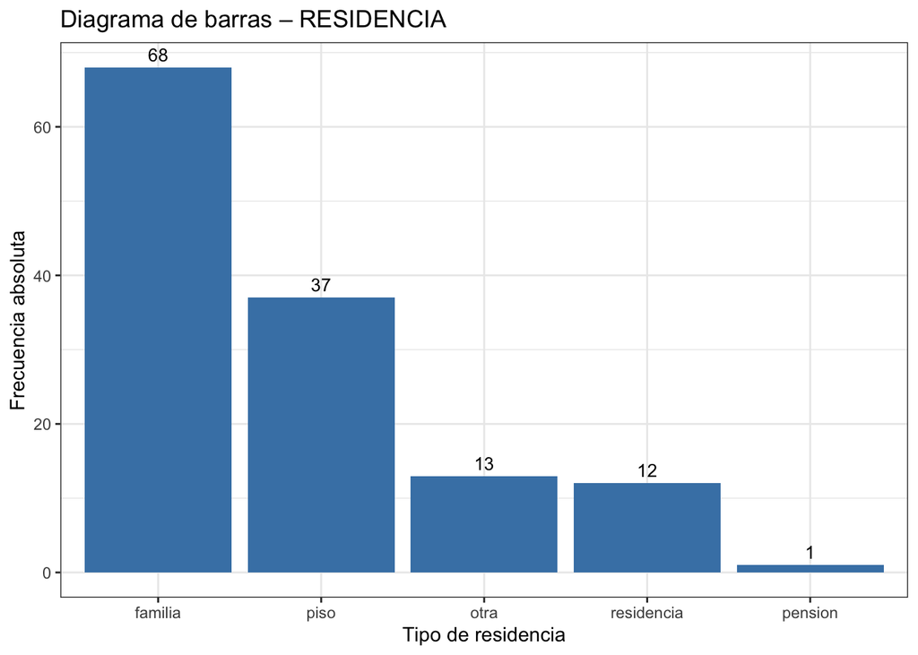

```r
ggplot(datos %>% filter(RESIDENCIA != ""),
       aes(x = reorder(RESIDENCIA, RESIDENCIA, function(x) -length(x)))) +
  geom_bar(fill = "steelblue") +
  geom_text(stat = "count", aes(label = ..count..), vjust = -0.5, size = 3.5) +
  labs(title = "Diagrama de barras – RESIDENCIA",
       x = "Tipo de residencia",
       y = "Frecuencia absoluta") +
  theme_bw()
```

### Diagrama de sectores

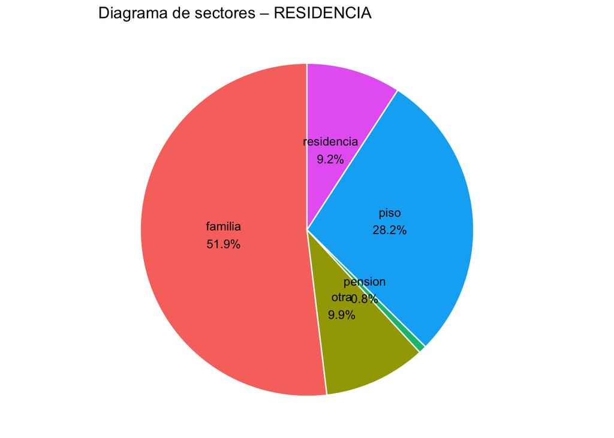

```r
tabla_res_plot <- datos %>%
  filter(!is.na(RESIDENCIA), RESIDENCIA != "") %>%
  count(RESIDENCIA) %>%
  mutate(
    pct   = round(n / sum(n) * 100, 1),
    label = paste0(RESIDENCIA, "\n", pct, "%")
  )

ggplot(tabla_res_plot, aes(x = "", y = n, fill = RESIDENCIA)) +
  geom_col(width = 1, color = "white") +
  coord_polar(theta = "y") +
  geom_text(aes(label = label),
            position = position_stack(vjust = 0.5), size = 3.5) +
  labs(title = "Diagrama de sectores – RESIDENCIA") +
  theme_void() +
  theme(legend.position = "none")
```

La mayoría de los alumnos viven con su **familia**, seguidos de los que están en un **piso**.

## 2.3. Variables cuantitativas

Analizamos la variable **PESO**, que es continua.

### Tabla de frecuencias con clases

En Statgraphics se pedían 10 tramos, límite inferior 40 y superior 95. Hacemos lo mismo:

```r
breaks_peso <- seq(40, 95, length.out = 11)
peso_limpio <- datos$PESO[!is.na(datos$PESO)]
clases      <- cut(peso_limpio, breaks = breaks_peso, include.lowest = TRUE, right = FALSE)

tabla_peso <- as.data.frame(table(Clase = clases)) %>%
  mutate(
    Frec_rel      = round(Freq / sum(Freq) * 100, 2),
    Frec_acum     = cumsum(Freq),
    Frec_rel_acum = cumsum(Frec_rel)
  ) %>%
  rename(Frec_abs = Freq)

kable(tabla_peso,
      col.names = c("Clase (intervalo)", "Frec. absoluta", "Frec. relativa (%)",
                    "Frec. abs. acumulada", "Frec. rel. acumulada (%)"),
      caption   = "Tabla de frecuencias – PESO (10 clases, de 40 a 95 kg)")
```

Tabla de frecuencias – PESO (10 clases, de 40 a 95 kg)

| Clase (intervalo) | Frec. absoluta | Frec. relativa (%) | Frec. abs. acumulada | Frec. rel. acumulada (%) |
| --- | --- | --- | --- | --- |
| [40,45.5) | 1 | 0.76 | 1 | 0.76 |
| [45.5,51) | 9 | 6.87 | 10 | 7.63 |
| [51,56.5) | 21 | 16.03 | 31 | 23.66 |
| [56.5,62) | 14 | 10.69 | 45 | 34.35 |
| [62,67.5) | 25 | 19.08 | 70 | 53.43 |
| [67.5,73) | 23 | 17.56 | 93 | 70.99 |
| [73,78.5) | 22 | 16.79 | 115 | 87.78 |
| [78.5,84) | 7 | 5.34 | 122 | 93.12 |
| [84,89.5) | 7 | 5.34 | 129 | 98.46 |
| [89.5,95] | 2 | 1.53 | 131 | 99.99 |

> **Interpretación de la Clase 3:** la frecuencia absoluta indica cuántos alumnos tienen un peso dentro de ese intervalo; la relativa, qué porcentaje representan sobre el total; las acumuladas van sumando desde la primera clase hasta esa.

### Histograma – todos los alumnos

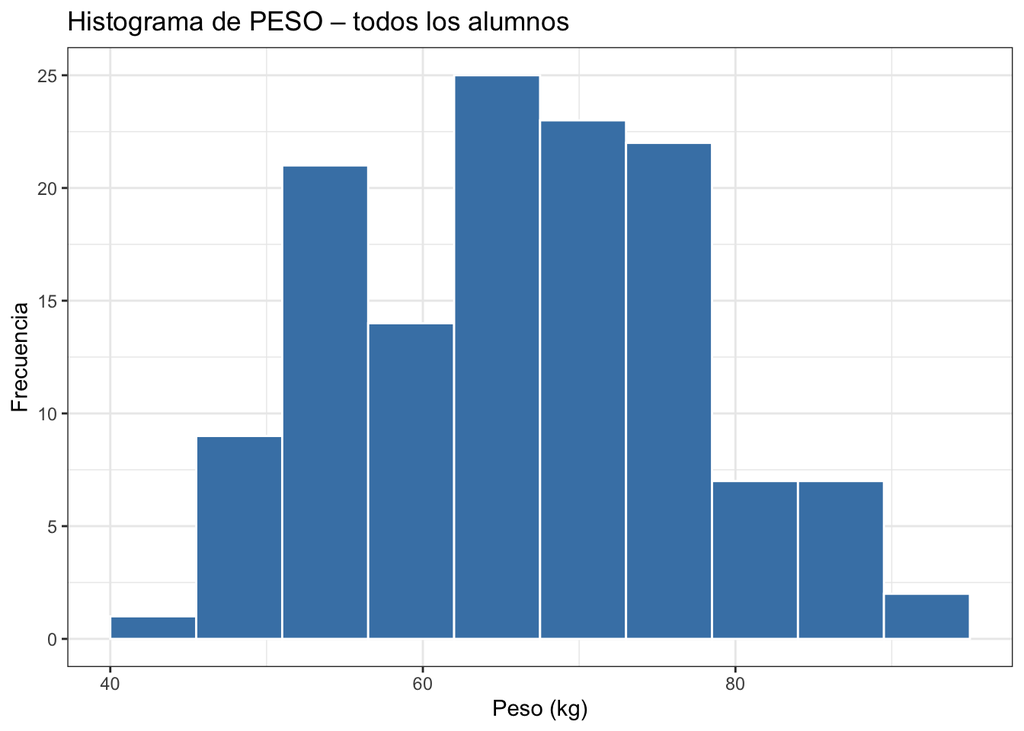

```r
ggplot(datos, aes(x = PESO)) +
  geom_histogram(breaks = breaks_peso, closed = "left",
                 fill = "steelblue", color = "white") +
  labs(title = "Histograma de PESO – todos los alumnos",
       x = "Peso (kg)", y = "Frecuencia") +
  theme_bw()
```

> **Para pensar…** La distribución se concentra entre 60 y 75 kg, con una ligera asimetría hacia la derecha. No se aprecian valores claramente anómalos.

### Histograma – solo chicos

En Statgraphics se usaba el campo `Selección: SEXO="chicos"`. En R simplemente filtramos:

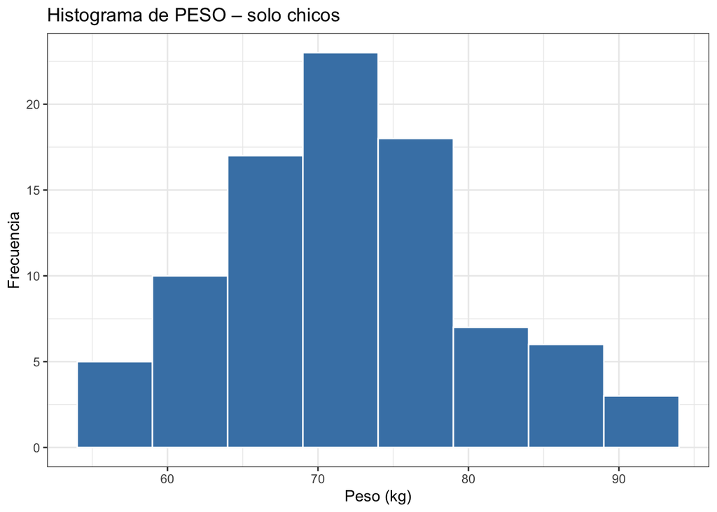

```r
datos_chicos  <- datos %>% filter(SEXO == "chicos", !is.na(PESO))
breaks_chicos <- seq(54, 94, length.out = 9)

ggplot(datos_chicos, aes(x = PESO)) +
  geom_histogram(breaks = breaks_chicos, closed = "left",
                 fill = "steelblue", color = "white") +
  labs(title = "Histograma de PESO – solo chicos",
       x = "Peso (kg)", y = "Frecuencia") +
  theme_bw()
```

> **Para pensar…** Comparado con el histograma de todos los alumnos, el de los chicos se desplaza hacia la derecha (pesos más altos). La distribución es algo más simétrica.

### Polígono de frecuencias acumuladas – chicos

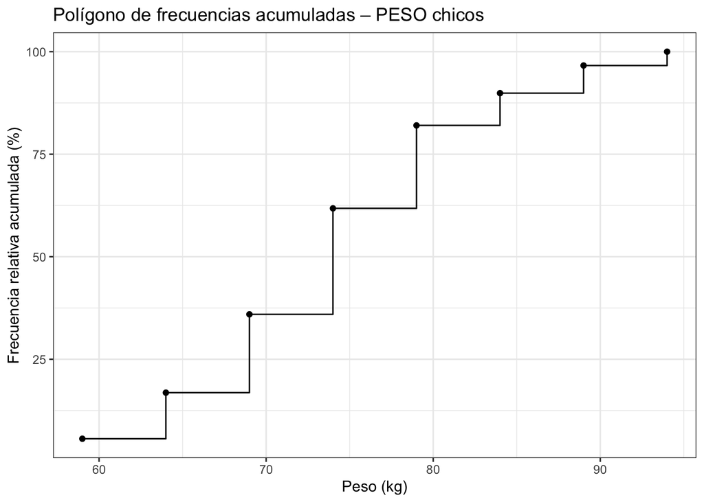

```r
clases_chicos <- cut(datos_chicos$PESO, breaks = breaks_chicos,
                     include.lowest = TRUE, right = FALSE)

tabla_chicos <- as.data.frame(table(clases_chicos)) %>%
  mutate(
    frec_rel_acum = cumsum(Freq) / sum(Freq) * 100,
    limite_sup    = breaks_chicos[-1]
  )

ggplot(tabla_chicos, aes(x = limite_sup, y = frec_rel_acum)) +
  geom_step() +
  geom_point() +
  labs(title = "Polígono de frecuencias acumuladas – PESO chicos",
       x = "Peso (kg)", y = "Frecuencia relativa acumulada (%)") +
  theme_bw()
```

### Percentiles – chicos

```r
p_chicos <- quantile(datos_chicos$PESO,
                     probs = c(0.10, 0.25, 0.50, 0.75, 0.90),
                     na.rm = TRUE)

tabla_p <- data.frame(
  Percentil = c("P10", "P25 (Q1)", "P50 (mediana)", "P75 (Q3)", "P90"),
  Valor_kg  = as.numeric(p_chicos)
)

kable(tabla_p, caption = "Percentiles del PESO de los chicos")
```

Percentiles del PESO de los chicos

| Percentil | Valor_kg |
| --- | --- |
| P10 | 60.8 |
| P25 (Q1) | 66.0 |
| P50 (mediana) | 71.0 |
| P75 (Q3) | 76.0 |
| P90 | 81.6 |

> **Para pensar…** Los percentiles son la lectura inversa del polígono acumulado: si el polígono llega al 75% en el peso X, entonces P75 = X.

### Medidas resumen – todos los alumnos

En Statgraphics teníamos el panel *Resumen Estadístico*:

```r
peso_all <- datos$PESO[!is.na(datos$PESO)]

moda <- function(x) {
  tbl <- table(x)
  as.numeric(names(tbl)[which.max(tbl)])
}

resumen_peso <- data.frame(
  Estadistico = c("Media", "Mediana", "Moda",
                  "Desv. estándar", "Varianza", "Coef. de variación (%)",
                  "Mínimo", "Máximo", "Rango",
                  "Q1", "Q3", "Rango intercuartílico",
                  "Sesgo estandarizado", "Curtosis estandarizada"),
  Tipo        = c("Posición", "Posición", "Posición",
                  "Dispersión", "Dispersión", "Dispersión",
                  "Dispersión", "Dispersión", "Dispersión",
                  "Posición/Dispersión", "Posición/Dispersión", "Dispersión",
                  "Forma", "Forma"),
  Robusto     = c("No", "Sí", "Sí",
                  "No", "No", "No",
                  "Sí", "Sí", "No",
                  "Sí", "Sí", "Sí",
                  "No", "No"),
  Valor = c(
    round(mean(peso_all), 3),
    round(median(peso_all), 3),
    round(moda(peso_all), 3),
    round(sd(peso_all), 3),
    round(var(peso_all), 3),
    round(sd(peso_all) / mean(peso_all) * 100, 3),
    round(min(peso_all), 3),
    round(max(peso_all), 3),
    round(diff(range(peso_all)), 3),
    round(quantile(peso_all, 0.25), 3),
    round(quantile(peso_all, 0.75), 3),
    round(IQR(peso_all), 3),
    round((mean(peso_all) - median(peso_all)) / sd(peso_all) * 3, 3),
    round((mean((peso_all - mean(peso_all))^4) / sd(peso_all)^4) - 3, 3)
  )
)

kable(resumen_peso,
      col.names = c("Estadístico", "Tipo de parámetro", "¿Robusto?", "Valor"),
      caption   = "Medidas resumen – PESO (todos los alumnos)")
```

Medidas resumen – PESO (todos los alumnos)

| Estadístico | Tipo de parámetro | ¿Robusto? | Valor |
| --- | --- | --- | --- |
| Media | Posición | No | 66.214 |
| Mediana | Posición | Sí | 66.000 |
| Moda | Posición | Sí | 70.000 |
| Desv. estándar | Dispersión | No | 10.657 |
| Varianza | Dispersión | No | 113.569 |
| Coef. de variación (%) | Dispersión | No | 16.095 |
| Mínimo | Dispersión | Sí | 45.000 |
| Máximo | Dispersión | Sí | 90.000 |
| Rango | Dispersión | No | 45.000 |
| Q1 | Posición/Dispersión | Sí | 57.000 |
| Q3 | Posición/Dispersión | Sí | 74.000 |
| Rango intercuartílico | Dispersión | Sí | 17.000 |
| Sesgo estandarizado | Forma | No | 0.060 |
| Curtosis estandarizada | Forma | No | -0.690 |

> **Para pensar…** Los **robustos** (mediana, IQR, cuartiles) no se ven afectados por valores extremos; los **no robustos** (media, desviación típica) sí. Si hubiera outliers claros convendría usar mediana e IQR.

### Diagrama de Caja y Bigotes

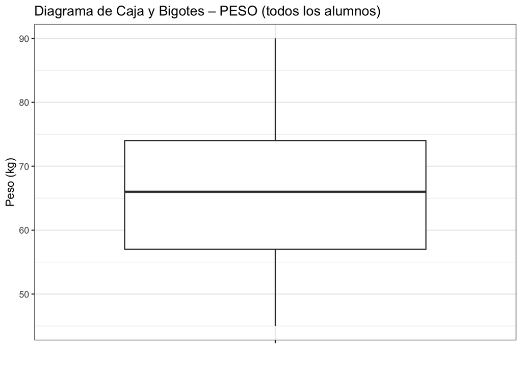

```r
ggplot(datos, aes(x = "", y = PESO)) +
  geom_boxplot(outlier.color = "red") +
  labs(title = "Diagrama de Caja y Bigotes – PESO (todos los alumnos)",
       x = "", y = "Peso (kg)") +
  theme_bw()
```

> **Para pensar…** La caja va del Q1 al Q3, la línea central es la mediana y los puntos rojos son *outliers*. Para describir el peso del alumnado lo más adecuado es usar **mediana** (posición) y **rango intercuartílico** (dispersión) por ser robustos.